# Table of Contents

## Описание проекта

Крупный интернет - магазин продает компьютерные игры по всему миру.

Из открытых источников доступны исторические данные о продажах игр, оценки пользователей и экспертов, жанры и платформы (например, Xbox или PlayStation).

Перед нами данные до 2016 года, и вы планируете кампанию на 2017-й.

Задача:

- выявить определяющие успешность игры закономерности
- сделать ставку на потенциально популярный продукт
- спланировать рекламные кампании.

## Общая информация

### Подключим библиотеки

```python
import pandas as pd
import numpy as np
import matplotlib.pyplot as plt
import math

import seaborn as sns
import datetime as dt
from scipy import stats as st
```

### Прочитаем файл

```python
try:
    df = pd.read_csv('c:/Users/User/Desktop/Практикум/Сборный проект 1/games.csv', sep = ',')
except:
    df = pd.read_csv('/datasets/games.csv', sep = ',')
df.head()
```

|  | Name | Platform | Year_of_Release | Genre | NA_sales | EU_sales | JP_sales | Other_sales | Critic_Score | User_Score | Rating |
| --- | --- | --- | --- | --- | --- | --- | --- | --- | --- | --- | --- |
| 0 | Wii Sports | Wii | 2006.0 | Sports | 41.36 | 28.96 | 3.77 | 8.45 | 76.0 | 8 | E |
| 1 | Super Mario Bros. | NES | 1985.0 | Platform | 29.08 | 3.58 | 6.81 | 0.77 | NaN | NaN | NaN |
| 2 | Mario Kart Wii | Wii | 2008.0 | Racing | 15.68 | 12.76 | 3.79 | 3.29 | 82.0 | 8.3 | E |
| 3 | Wii Sports Resort | Wii | 2009.0 | Sports | 15.61 | 10.93 | 3.28 | 2.95 | 80.0 | 8 | E |
| 4 | Pokemon Red/Pokemon Blue | GB | 1996.0 | Role-Playing | 11.27 | 8.89 | 10.22 | 1.00 | NaN | NaN | NaN |

### Описание данных

• Name — название игры

• Platform — платформа

• Year_of_Release — год выпуска

• Genre — жанр игры

• NA_sales — продажи в Северной Америке (миллионы проданных копий)

• EU_sales — продажи в Европе (миллионы проданных копий)

• JP_sales — продажи в Японии (миллионы проданных копий)

• Other_sales — продажи в других странах (миллионы проданных копий)

• Critic_Score — оценка критиков (максимум 100)

• User_Score — оценка пользователей (максимум 10)

• Rating — рейтинг от организации ESRB (англ. Entertainment Software Rating Board). Эта ассоциация определяет рейтинг компьютерных игр и присваивает им подходящую возрастную категорию.

```python
df.info()
```

```
<class 'pandas.core.frame.DataFrame'>
RangeIndex: 16715 entries, 0 to 16714
Data columns (total 11 columns):
 #   Column           Non-Null Count  Dtype
---  ------           --------------  -----
 0   Name             16713 non-null  object
 1   Platform         16715 non-null  object
 2   Year_of_Release  16446 non-null  float64
 3   Genre            16713 non-null  object
 4   NA_sales         16715 non-null  float64
 5   EU_sales         16715 non-null  float64
 6   JP_sales         16715 non-null  float64
 7   Other_sales      16715 non-null  float64
 8   Critic_Score     8137 non-null   float64
 9   User_Score       10014 non-null  object
 10  Rating           9949 non-null   object
dtypes: float64(6), object(5)
memory usage: 1.4+ MB
```

```python
df.nunique()
```

```
Name               11559
Platform              31
Year_of_Release       37
Genre                 12
NA_sales             402
EU_sales             307
JP_sales             244
Other_sales          155
Critic_Score          82
User_Score            96
Rating                 8
dtype: int64
```

```python
df.isnull().sum()
```

```
Name                  2
Platform              0
Year_of_Release     269
Genre                 2
NA_sales              0
EU_sales              0
JP_sales              0
Other_sales           0
Critic_Score       8578
User_Score         6701
Rating             6766
dtype: int64
```

```python
df.describe(include = "all")
```

|  | Name | Platform | Year_of_Release | Genre | NA_sales | EU_sales | JP_sales | Other_sales | Critic_Score | User_Score | Rating |
| --- | --- | --- | --- | --- | --- | --- | --- | --- | --- | --- | --- |
| count | 16713 | 16715 | 16446.000000 | 16713 | 16715.000000 | 16715.000000 | 16715.000000 | 16715.000000 | 8137.000000 | 10014 | 9949 |
| unique | 11559 | 31 | NaN | 12 | NaN | NaN | NaN | NaN | NaN | 96 | 8 |
| top | Need for Speed: Most Wanted | PS2 | NaN | Action | NaN | NaN | NaN | NaN | NaN | tbd | E |
| freq | 12 | 2161 | NaN | 3369 | NaN | NaN | NaN | NaN | NaN | 2424 | 3990 |
| mean | NaN | NaN | 2006.484616 | NaN | 0.263377 | 0.145060 | 0.077617 | 0.047342 | 68.967679 | NaN | NaN |
| std | NaN | NaN | 5.877050 | NaN | 0.813604 | 0.503339 | 0.308853 | 0.186731 | 13.938165 | NaN | NaN |
| min | NaN | NaN | 1980.000000 | NaN | 0.000000 | 0.000000 | 0.000000 | 0.000000 | 13.000000 | NaN | NaN |
| 25% | NaN | NaN | 2003.000000 | NaN | 0.000000 | 0.000000 | 0.000000 | 0.000000 | 60.000000 | NaN | NaN |
| 50% | NaN | NaN | 2007.000000 | NaN | 0.080000 | 0.020000 | 0.000000 | 0.010000 | 71.000000 | NaN | NaN |
| 75% | NaN | NaN | 2010.000000 | NaN | 0.240000 | 0.110000 | 0.040000 | 0.030000 | 79.000000 | NaN | NaN |
| max | NaN | NaN | 2016.000000 | NaN | 41.360000 | 28.960000 | 10.220000 | 10.570000 | 98.000000 | NaN | NaN |

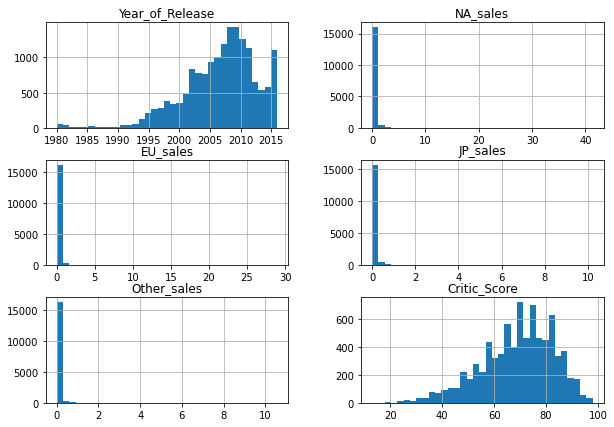

```python
df.hist(bins= 35, figsize=(10, 7));
```

### Вывод:

В файле содержатся 16715 записей с данными о наименовании игр, платформах, количестве покупателей, жанре, года выпуска и рейтингами.

Необходимо:

1. столбцы привести к "змеиному регистру"
2. удалить пропуски в колонке с именем, жанром и годом выпуска, так как эти данные мы не можем восстановить. Была идея пройти по наименованиям игр и восстановить дату выпуска соответствующую, но уникальных значений имени 11,5 тысяч. Такую инфомацию собрать не получится.
3. в колонке оценки пользователями есть странное обозначение "TBD", что является аббревиатурой To Be Decided (решение будет позже). Соответственно вместо "TBD" будет отсутствующее значение.
4. в колонках Critic_Score, User_Score, Rating большое количество пропусков.
5. после замен, обработаем типы данных.

## Предообработка данных

### Переименование столбцов

```python
df.columns = df.columns.str.lower()
df.head(3)
```

|  | name | platform | year_of_release | genre | na_sales | eu_sales | jp_sales | other_sales | critic_score | user_score | rating |
| --- | --- | --- | --- | --- | --- | --- | --- | --- | --- | --- | --- |
| 0 | Wii Sports | Wii | 2006.0 | Sports | 41.36 | 28.96 | 3.77 | 8.45 | 76.0 | 8 | E |
| 1 | Super Mario Bros. | NES | 1985.0 | Platform | 29.08 | 3.58 | 6.81 | 0.77 | NaN | NaN | NaN |
| 2 | Mario Kart Wii | Wii | 2008.0 | Racing | 15.68 | 12.76 | 3.79 | 3.29 | 82.0 | 8.3 | E |

```python
df['name']=df['name'].str.lower()
df.head(3)
```

|  | name | platform | year_of_release | genre | na_sales | eu_sales | jp_sales | other_sales | critic_score | user_score | rating |
| --- | --- | --- | --- | --- | --- | --- | --- | --- | --- | --- | --- |
| 0 | wii sports | Wii | 2006.0 | Sports | 41.36 | 28.96 | 3.77 | 8.45 | 76.0 | 8 | E |
| 1 | super mario bros. | NES | 1985.0 | Platform | 29.08 | 3.58 | 6.81 | 0.77 | NaN | NaN | NaN |
| 2 | mario kart wii | Wii | 2008.0 | Racing | 15.68 | 12.76 | 3.79 | 3.29 | 82.0 | 8.3 | E |

```python
df['platform']=df['platform'].str.lower()
df.head(3)
```

|  | name | platform | year_of_release | genre | na_sales | eu_sales | jp_sales | other_sales | critic_score | user_score | rating |
| --- | --- | --- | --- | --- | --- | --- | --- | --- | --- | --- | --- |
| 0 | wii sports | wii | 2006.0 | Sports | 41.36 | 28.96 | 3.77 | 8.45 | 76.0 | 8 | E |
| 1 | super mario bros. | nes | 1985.0 | Platform | 29.08 | 3.58 | 6.81 | 0.77 | NaN | NaN | NaN |
| 2 | mario kart wii | wii | 2008.0 | Racing | 15.68 | 12.76 | 3.79 | 3.29 | 82.0 | 8.3 | E |

### Удаление пропусков

```python
df_isnull_name = df[df['name'].isna()]
df_isnull_name
```

|  | name | platform | year_of_release | genre | na_sales | eu_sales | jp_sales | other_sales | critic_score | user_score | rating |
| --- | --- | --- | --- | --- | --- | --- | --- | --- | --- | --- | --- |
| 659 | NaN | gen | 1993.0 | NaN | 1.78 | 0.53 | 0.00 | 0.08 | NaN | NaN | NaN |
| 14244 | NaN | gen | 1993.0 | NaN | 0.00 | 0.00 | 0.03 | 0.00 | NaN | NaN | NaN |

```python
df_isnull_genre = df[df['genre'].isna()]
df_isnull_genre
```

|  | name | platform | year_of_release | genre | na_sales | eu_sales | jp_sales | other_sales | critic_score | user_score | rating |
| --- | --- | --- | --- | --- | --- | --- | --- | --- | --- | --- | --- |
| 659 | NaN | gen | 1993.0 | NaN | 1.78 | 0.53 | 0.00 | 0.08 | NaN | NaN | NaN |
| 14244 | NaN | gen | 1993.0 | NaN | 0.00 | 0.00 | 0.03 | 0.00 | NaN | NaN | NaN |

```python
df_isnull_year_of_release = df[df['year_of_release'].isna()]
df_isnull_year_of_release.describe()
```

|  | year_of_release | na_sales | eu_sales | jp_sales | other_sales | critic_score |
| --- | --- | --- | --- | --- | --- | --- |
| count | 0.0 | 269.000000 | 269.000000 | 269.000000 | 269.000000 | 154.000000 |
| mean | NaN | 0.219888 | 0.090929 | 0.024907 | 0.032007 | 67.584416 |
| std | NaN | 0.424907 | 0.207933 | 0.090160 | 0.075546 | 14.828740 |
| min | NaN | 0.000000 | 0.000000 | 0.000000 | 0.000000 | 22.000000 |
| 25% | NaN | 0.010000 | 0.000000 | 0.000000 | 0.000000 | 57.000000 |
| 50% | NaN | 0.090000 | 0.020000 | 0.000000 | 0.010000 | 70.000000 |
| 75% | NaN | 0.240000 | 0.100000 | 0.000000 | 0.030000 | 78.000000 |
| max | NaN | 4.260000 | 2.360000 | 0.770000 | 0.710000 | 94.000000 |

```python
df = df.dropna(subset=['year_of_release'])
df = df.dropna(subset=['name'])

df = df.reset_index(drop=True)
```

```python
df.isnull().sum()
```

```
name                  0
platform              0
year_of_release       0
genre                 0
na_sales              0
eu_sales              0
jp_sales              0
other_sales           0
critic_score       8461
user_score         6605
rating             6676
dtype: int64
```

Удалили пропуски в колонках name и genre, так как количество маленькое, по 2 пропуска, восстанавливать или изменять нет необходимости.

Удалили пропуски в колонке year_of_release, так как восстановить год не возможно. Средним или медианным заменять не целесообразно.

Пропуски в рейтингах и оценках не стала менять на 0 или "нет данных", так будет удобно обращаться к данным колонкам для анализа.

В этих колонках пропуски возникли скорее всего по причине того, что пользователи не давали оценку играм. Почему категории возраста охватили не все игры, затруднительно сказать, вероятно надо посмотреть даты выхода игр, возможно до какого-то года ранее (или нескольких) не существовало рейтинга по возрастам.

```python
df.pivot_table(index = 'genre', values = 'critic_score', aggfunc = ['mean','median'])
```

| genre | mean critic_score | median critic_score |
| --- | --- | --- |
| Action | 66.676931 | 68.0 |
| Adventure | 65.268750 | 66.0 |
| Fighting | 69.155556 | 72.0 |
| Misc | 66.648330 | 69.0 |
| Platform | 68.124490 | 69.5 |
| Puzzle | 67.231818 | 70.0 |
| Racing | 68.006897 | 69.0 |
| Role-Playing | 72.655267 | 74.0 |
| Shooter | 70.260022 | 73.0 |
| Simulation | 68.609195 | 70.0 |
| Sports | 71.993133 | 75.0 |
| Strategy | 72.158784 | 73.0 |

### Замена 'tbd'

```python
df.loc[df['user_score']=='tbd', 'user_score'] = 'nan'
df['user_score'].unique()
```

```
array(['8', nan, '8.3', '8.5', '6.6', '8.4', '8.6', '7.7', '6.3', '7.4',
       '8.2', '9', '7.9', '8.1', '8.7', '7.1', '3.4', '5.3', '4.8', '3.2',
       '8.9', '6.4', '7.8', '7.5', '2.6', '7.2', '9.2', '7', '7.3', '4.3',
       '7.6', '5.7', '5', '9.1', '6.5', 'nan', '8.8', '6.9', '9.4', '6.8',
       '6.1', '6.7', '5.4', '4', '4.9', '4.5', '9.3', '6.2', '4.2', '6',
       '3.7', '4.1', '5.8', '5.6', '5.5', '4.4', '4.6', '5.9', '3.9',
       '3.1', '2.9', '5.2', '3.3', '4.7', '5.1', '3.5', '2.5', '1.9', '3',
       '2.7', '2.2', '2', '9.5', '2.1', '3.6', '2.8', '1.8', '3.8', '0',
       '1.6', '9.6', '2.4', '1.7', '1.1', '0.3', '1.5', '0.7', '1.2',
       '2.3', '0.5', '1.3', '0.2', '0.6', '1.4', '0.9', '1', '9.7'],
      dtype=object)
```

"TBD" является аббревиатурой To Be Decided (решение будет позже). Соответственно вместо "TBD" необходимо поставить значение "отсутствует оценка", поэтому проведена замена на nan.

### Замена типа данных

```python
df['year_of_release'] = df['year_of_release'].astype(int)
df['user_score'] = df['user_score'].astype(float)
#df['rating'] = df['rating'].astype('category')
```

```python
df.info()
```

```
<class 'pandas.core.frame.DataFrame'>
RangeIndex: 16444 entries, 0 to 16443
Data columns (total 11 columns):
 #   Column           Non-Null Count  Dtype
---  ------           --------------  -----
 0   name             16444 non-null  object
 1   platform         16444 non-null  object
 2   year_of_release  16444 non-null  int64
 3   genre            16444 non-null  object
 4   na_sales         16444 non-null  float64
 5   eu_sales         16444 non-null  float64
 6   jp_sales         16444 non-null  float64
 7   other_sales      16444 non-null  float64
 8   critic_score     7983 non-null   float64
 9   user_score       7463 non-null   float64
 10  rating           9768 non-null   object
dtypes: float64(6), int64(1), object(4)
memory usage: 1.4+ MB
```

Заменили тип данных в колонке year_of_release с вещественного на целочисленные значения, т.к. год с запятой быть не должен.

Заменили тип данных в колонке user_score на вещественный вместо object.

```python
df.duplicated().sum()
```

```
0
```

Явных дубликатов нет

```python
df_dubl_name = df.duplicated(subset=['name','platform','year_of_release'])
df_dubl_name.value_counts()
```

```
False    16443
True         1
dtype: int64
```

```python
df_duplicates = df[df.duplicated({'name','platform','year_of_release'},keep=False)]
df_duplicates
```

|  | name | platform | year_of_release | genre | na_sales | eu_sales | jp_sales | other_sales | critic_score | user_score | rating |
| --- | --- | --- | --- | --- | --- | --- | --- | --- | --- | --- | --- |
| 600 | madden nfl 13 | ps3 | 2012 | Sports | 2.11 | 0.22 | 0.0 | 0.23 | 83.0 | 5.5 | E |
| 15969 | madden nfl 13 | ps3 | 2012 | Sports | 0.00 | 0.01 | 0.0 | 0.00 | 83.0 | 5.5 | E |

```python
df = df.drop(index=[15969])
```

```python
df_dubl_name = df.duplicated(subset=['name','platform','year_of_release'])
df_dubl_name.value_counts()
```

```
False    16443
dtype: int64
```

```python
df['sum_sales'] = df['na_sales']+df['eu_sales']+df['jp_sales']+df['other_sales']
df.head()
```

|  | name | platform | year_of_release | genre | na_sales | eu_sales | jp_sales | other_sales | critic_score | user_score | rating | sum_sales |
| --- | --- | --- | --- | --- | --- | --- | --- | --- | --- | --- | --- | --- |
| 0 | wii sports | wii | 2006 | Sports | 41.36 | 28.96 | 3.77 | 8.45 | 76.0 | 8.0 | E | 82.54 |
| 1 | super mario bros. | nes | 1985 | Platform | 29.08 | 3.58 | 6.81 | 0.77 | NaN | NaN | NaN | 40.24 |
| 2 | mario kart wii | wii | 2008 | Racing | 15.68 | 12.76 | 3.79 | 3.29 | 82.0 | 8.3 | E | 35.52 |
| 3 | wii sports resort | wii | 2009 | Sports | 15.61 | 10.93 | 3.28 | 2.95 | 80.0 | 8.0 | E | 32.77 |
| 4 | pokemon red/pokemon blue | gb | 1996 | Role-Playing | 11.27 | 8.89 | 10.22 | 1.00 | NaN | NaN | NaN | 31.38 |

```python
# check
df.info()
```

```
<class 'pandas.core.frame.DataFrame'>
Int64Index: 16443 entries, 0 to 16443
Data columns (total 12 columns):
 #   Column           Non-Null Count  Dtype
---  ------           --------------  -----
 0   name             16443 non-null  object
 1   platform         16443 non-null  object
 2   year_of_release  16443 non-null  int64
 3   genre            16443 non-null  object
 4   na_sales         16443 non-null  float64
 5   eu_sales         16443 non-null  float64
 6   jp_sales         16443 non-null  float64
 7   other_sales      16443 non-null  float64
 8   critic_score     7982 non-null   float64
 9   user_score       7462 non-null   float64
 10  rating           9767 non-null   object
 11  sum_sales        16443 non-null  float64
dtypes: float64(7), int64(1), object(4)
memory usage: 1.6+ MB
```

```python
df['rating'].unique()
```

```
array(['E', nan, 'M', 'T', 'E10+', 'K-A', 'AO', 'EC', 'RP'], dtype=object)
```

```python
df.loc[df['rating'] == 'K-A', 'rating'] = 'E'
df['rating'].value_counts()
```

```
E       3923
T       2905
M       1536
E10+    1393
EC         8
AO         1
RP         1
Name: rating, dtype: int64
```

Заменили рейтинг К-А на Е

```python
df.loc[df['rating'] == 'RP']
```

|  | name | platform | year_of_release | genre | na_sales | eu_sales | jp_sales | other_sales | critic_score | user_score | rating | sum_sales |
| --- | --- | --- | --- | --- | --- | --- | --- | --- | --- | --- | --- | --- |
| 14045 | supreme ruler: cold war | pc | 2011 | Strategy | 0.0 | 0.03 | 0.0 | 0.01 | 63.0 | 6.8 | RP | 0.04 |

```python
df = df.drop(index=[14045])
df['rating'].value_counts()
```

```
E       3923
T       2905
M       1536
E10+    1393
EC         8
AO         1
Name: rating, dtype: int64
```

```python
df_rat = df.pivot_table(index = ['platform','name'], values ='rating', aggfunc = {'max', 'count','min'})
df_rat.tail(5)
#df.pivot_tale(index = ['name','genre'], values = 'sum_sales')
```

| platform | name | count | max | min |
| --- | --- | --- | --- | --- |
| xone | xcom 2 | 1 | T | T |
|  | zombie army trilogy | 0 | NaN | NaN |
|  | zombiu | 0 | NaN | NaN |
|  | zoo tycoon (2013) | 0 | NaN | NaN |
|  | zumba fitness: world party | 1 | E | E |

### Вывод:

Проведена предобработка данных:

- выравнены регистры в столбцах и строках
- удалены пропуски
- заменены типы данных
- проведена замена некорректного значения в столбце с оценками пользователей
- проверены дубликаты и удален неявный дубликат
- добавлен столбец с общими продажами

## Исследовательский анализ данных

### Выпуск игр по годам

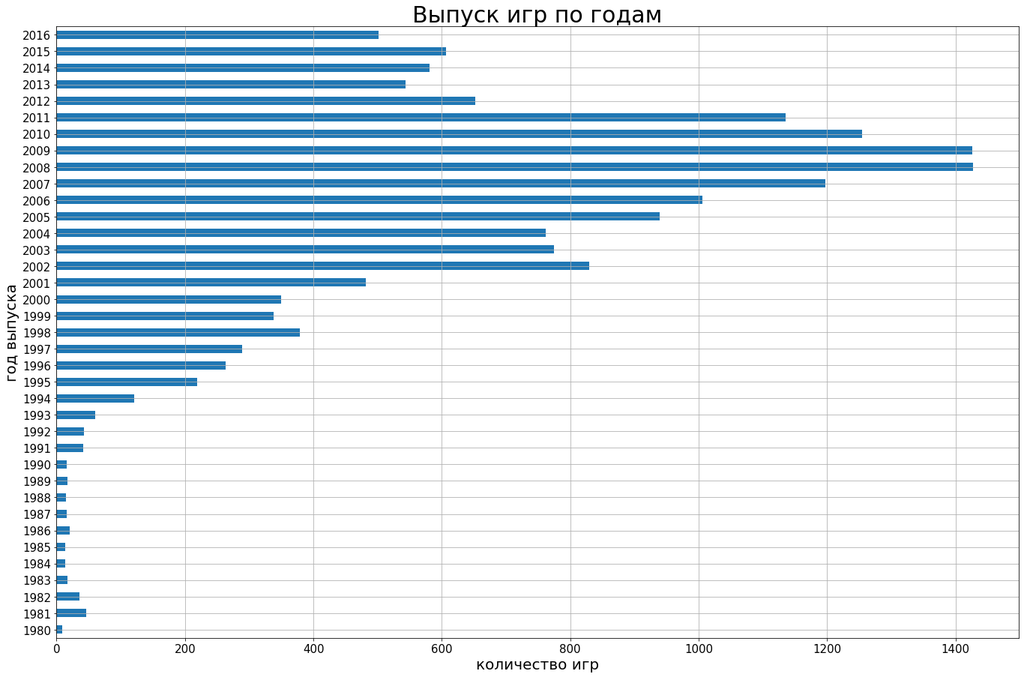

```python
df_year = df.pivot_table(index='year_of_release', values = 'name', aggfunc = 'count')

df_year.plot(kind = 'barh',figsize = (23,15),
              grid=True, legend = False, fontsize = 15);
plt.title('Выпуск игр по годам',fontsize = 30);
plt.xlabel('количество игр', fontsize = 20);
plt.ylabel('год выпуска', fontsize = 20);
```

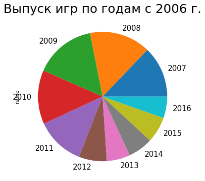

```python
df.query('year_of_release>2006').pivot_table(index='year_of_release', values = 'name',
                            aggfunc = 'count').plot(x = 'count', y = 'name', kind = 'pie',
                            figsize = (17,6),  grid=True, legend = False, fontsize = 15);
plt.title('Выпуск игр по годам с 2006 г.',fontsize = 25 );
```

Небольшое количество выпускаемых игр в 1981 году обяснимы, так же как и рост с 1993 года. Графики дают наглядное представления как быстро развивался рынок в следующие 15 лет. Но чем вызвано падение релизов после 2011 года?

Для анализа нам необходимо рассматривать 2015 и 2016 год, чтобы планировать ожидания 2017 года.

```python
relase = df.query('year_of_release>2015').pivot_table(index=['genre','name'], values = ['sum_sales','platform'],
                            aggfunc = ['sum','max'])
relase['sum'] = relase['sum'][relase['sum'] > 1.2]
relase = relase.dropna()
relase
```

| genre | name | sum sum_sales | max platform | max sum_sales |
| --- | --- | --- | --- | --- |
| Action | far cry: primal | 3.30 | xone | 2.26 |
|  | lego marvel's avengers | 2.19 | xone | 0.73 |
|  | lego star wars: the force awakens | 1.67 | xone | 0.71 |
|  | mafia iii | 2.63 | xone | 1.81 |
|  | no man's sky | 1.69 | ps4 | 1.69 |
|  | watch dogs 2 | 1.49 | xone | 1.13 |
|  | yokai watch 3 | 1.33 | 3ds | 1.33 |
| Fighting | naruto shippuden: ultimate ninja storm 4 | 1.45 | xone | 1.14 |
| Platform | ratchet & clank (2016) | 1.54 | ps4 | 1.54 |
| Role-Playing | dark souls iii | 2.12 | xone | 1.66 |
|  | pokemon sun/moon | 7.14 | 3ds | 7.14 |
|  | the elder scrolls v: skyrim | 2.07 | xone | 1.32 |
| Shooter | battlefield 1 | 6.70 | xone | 4.07 |
|  | call of duty: infinite warfare | 7.02 | xone | 4.47 |
|  | doom (2016) | 2.47 | xone | 1.49 |
|  | gears of war 4 | 1.34 | xone | 1.34 |
|  | overwatch | 3.73 | xone | 2.14 |
|  | titanfall 2 | 1.41 | xone | 0.76 |
|  | tom clancy's the division | 6.38 | xone | 3.80 |
|  | uncharted 4: a thief's end | 5.39 | ps4 | 5.39 |
| Sports | ea sports ufc 2 | 1.35 | xone | 0.93 |
|  | fifa 17 | 11.48 | xone | 7.60 |
|  | madden nfl 17 | 3.26 | xone | 1.74 |
|  | nba 2k17 | 3.16 | xone | 1.88 |

### Анализ по платформам

```python
df_platform = df.pivot_table(index='platform', values = 'sum_sales',
                             aggfunc ={'sum_sales':'sum'})
df_platform = df_platform.sort_values('sum_sales', ascending = False)
df_platform_top = df_platform.head(10)
df_platform_top
```

| platform | sum_sales |
| --- | --- |
| ps2 | 1233.56 |
| x360 | 961.24 |
| ps3 | 931.33 |
| wii | 891.18 |
| ds | 802.78 |
| ps | 727.58 |
| ps4 | 314.14 |
| gba | 312.88 |
| psp | 289.53 |
| 3ds | 257.81 |

Топ-10 платформ по сумме продаж за весь период.

Лидерами являются платформы PS2, X360 и PS3.

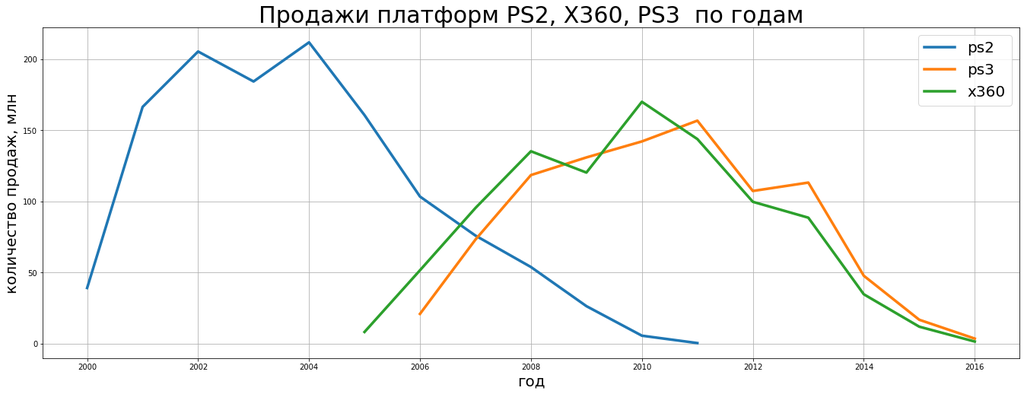

```python
df_2 = df.query("platform == ['ps2','x360','ps3']")
df_2.pivot_table(index='year_of_release', columns = 'platform', values = 'sum_sales',
                 aggfunc ='sum').plot(figsize = (23,8), grid=True, legend = True,linewidth=3.5);
plt.title('Продажи платформ PS2, X360, PS3  по годам',fontsize = 30);
plt.xlabel('год', fontsize = 20);
plt.ylabel('количество продаж, млн', fontsize = 20);
plt.legend(fontsize = 20);
```

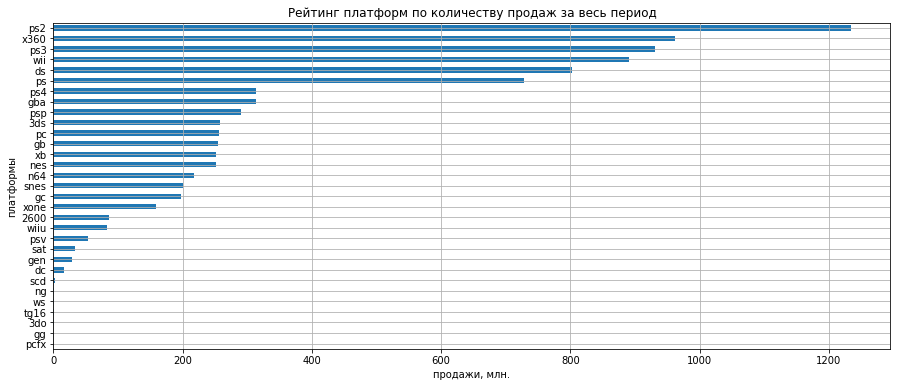

```python
df_sales = df.pivot_table(index='platform', values = 'sum_sales',aggfunc ='sum').sort_values('sum_sales')
df_sales.plot(kind = 'barh', grid=True, figsize = (15,6),legend = False,);
plt.title('Рейтинг платформ по количеству продаж за весь период');
plt.xlabel('продажи, млн.');
plt.ylabel('платформы');
```

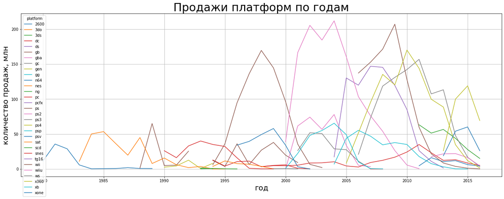

```python
df_1 = df.pivot_table(index=['year_of_release'], columns = 'platform', values = 'sum_sales',
aggfunc ='sum').plot(figsize = (23,8), grid=True, legend = True);
plt.title('Продажи платформ по годам',fontsize = 30);
plt.xlabel('год', fontsize = 20);
plt.ylabel('количество продаж, млн', fontsize = 20);
```

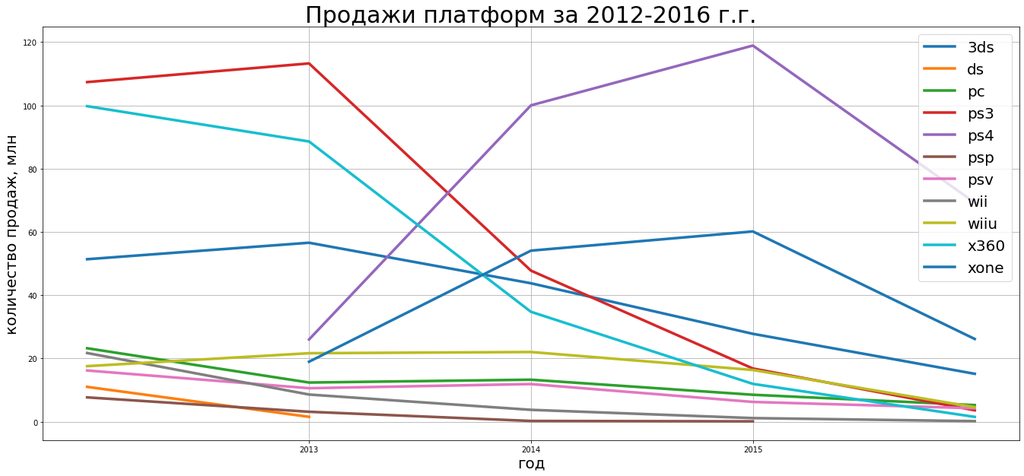

```python
df_1 = df.query('year_of_release > 2011') .pivot_table(index=['year_of_release'], columns = 'platform', values = 'sum_sales',
aggfunc ='sum').plot(figsize = (23,10), grid=True, legend = True,linewidth=3.5);
plt.title('Продажи платформ за 2012-2016 г.г.',fontsize = 30);
plt.xlabel('год', fontsize = 20);
plt.ylabel('количество продаж, млн', fontsize = 20);
plt.legend(fontsize = 20);
plt.xticks(np.arange(2013,2016,step=1));
```

```python
df_platform_life = df.pivot_table(index='year_of_release',columns = 'platform', values='sum_sales',
aggfunc='sum')
df_platform_life.count().sort_values(ascending = False).head(15)
```

```
platform
pc      26
gb      13
nes     12
x360    12
psp     12
ps2     12
wii     11
ds      11
ps3     11
2600    10
snes    10
ps      10
xb       9
gba      8
dc       7
dtype: int64
```

```python
df_platform_life.count().mean()
```

```
7.67741935483871
```

Платформы "не вечны", что явно видно на графике. Средней срок "жизни" платформы 7 лет. Есть "долгожители", очевидные РС, которыми мы продолжаем пользоваться в том числе и для игр).

C 2013 года появляются две главные на "данный" момент платформы PS4 и XOne.

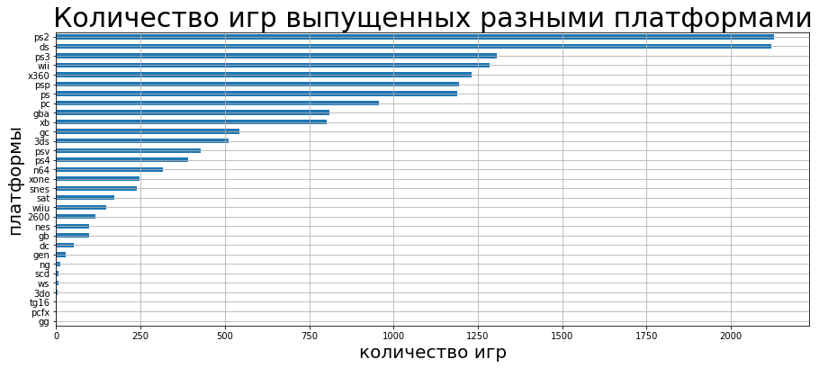

```python
df_count = df.pivot_table(index=['platform'], values = ['sum_sales'],aggfunc ='count').sort_values('sum_sales')
df_count.plot(kind = 'barh',figsize = (15,6),grid=True, legend = False);
plt.title('Количество игр выпущенных разными платформами',fontsize = 30);
plt.xlabel('количество игр', fontsize = 20);
plt.ylabel('платформы', fontsize = 20);
```

Интересно, что платформа DS обгоняет PS3 и X360 по количеству выпущенных игр. А вот продажи у этой платфомы ниже.

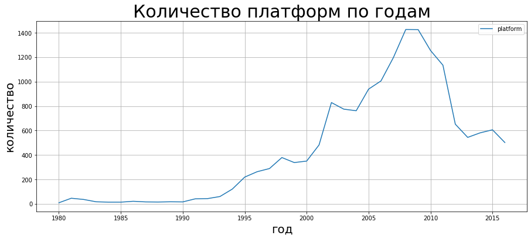

```python
df_1 = df.pivot_table(index=['year_of_release'], values = 'platform',
aggfunc ='count').plot(figsize = (15,6), grid=True, legend = True);
plt.title('Количество платформ по годам',fontsize = 30);
plt.xlabel('год', fontsize = 20);
plt.ylabel('количество', fontsize = 20);
```

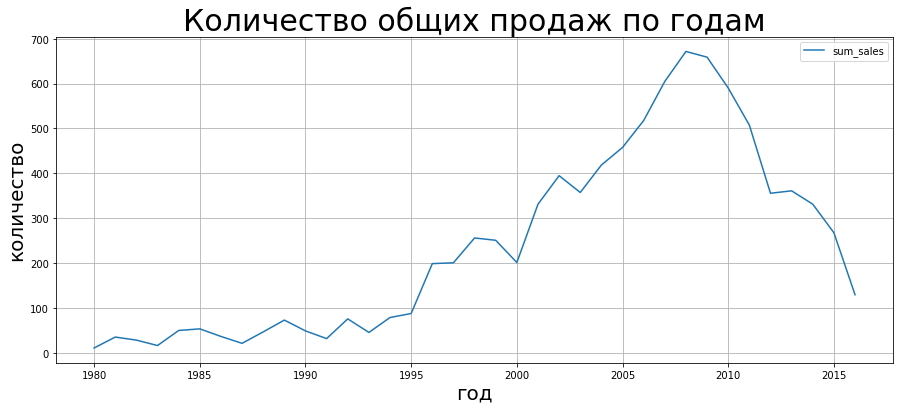

```python
df_1 = df.pivot_table(index=['year_of_release'], values = 'sum_sales',
aggfunc ='sum').plot(figsize = (15,6), grid=True, legend = True);
plt.title('Количество общих продаж по годам',fontsize = 30);
plt.xlabel('год', fontsize = 20);
plt.ylabel('количество', fontsize = 20);
```

Больше платформ == больше продаж, хотя в 2013 это правило несколько нарушаться.

### Лидеры продаж за актуальный период

Посмотрим что происходит с действующими платформами в этот период:

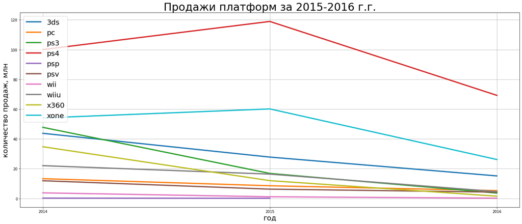

```python
df_1 = df.query('year_of_release > 2013') .pivot_table(index=['year_of_release'], columns = 'platform',
                                                       values = 'sum_sales',
aggfunc ='sum').plot(figsize = (25,10), grid=True, legend = True, linewidth=3.5);
plt.title('Продажи платформ за 2015-2016 г.г.',fontsize = 30);
plt.xlabel('год', fontsize = 20);
plt.ylabel('количество продаж, млн', fontsize = 20);
plt.legend(fontsize = 20, loc=2);
plt.xticks(np.arange(2014, 2017, step=1));
```

Лидерами среди платформ в актуальном периоде являются платформы PS4 и XOne.

Построим для этих платформ "ящик с усами":

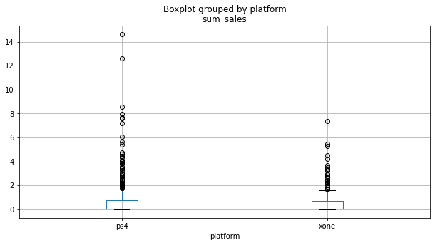

```python
df_box = df.query("platform == ['xone', 'ps4']")
df_box.boxplot(column='sum_sales', by='platform',figsize=(10,5));
```

Платформа PS4 дает больше выбросов по сравнению со второй платформой. Предположу, что это связано с большим количеством игр на первой платформе.

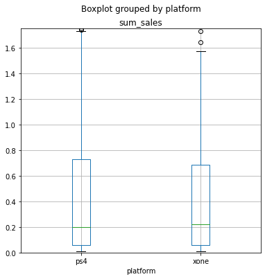

```python
df_box.boxplot(column='sum_sales', by='platform',figsize=(6,6));
plt.ylim(0,1.75);
plt.show()
```

Медиана лидирующих платформ находится на уровне 200 000 проданных копий

```python
df_box.query("platform == ['ps4']").describe()
```

|  | year_of_release | na_sales | eu_sales | jp_sales | other_sales | critic_score | user_score | sum_sales |
| --- | --- | --- | --- | --- | --- | --- | --- | --- |
| count | 392.000000 | 392.000000 | 392.000000 | 392.000000 | 392.000000 | 252.000000 | 257.000000 | 392.000000 |
| mean | 2015.145408 | 0.277398 | 0.359923 | 0.040714 | 0.123342 | 72.091270 | 6.748249 | 0.801378 |
| std | 0.868181 | 0.583723 | 0.810843 | 0.069101 | 0.254825 | 12.485992 | 1.459481 | 1.609456 |
| min | 2013.000000 | 0.000000 | 0.000000 | 0.000000 | 0.000000 | 19.000000 | 1.500000 | 0.010000 |
| 25% | 2015.000000 | 0.007500 | 0.000000 | 0.000000 | 0.010000 | 66.000000 | 6.100000 | 0.060000 |
| 50% | 2015.000000 | 0.060000 | 0.080000 | 0.010000 | 0.030000 | 73.000000 | 7.000000 | 0.200000 |
| 75% | 2016.000000 | 0.260000 | 0.300000 | 0.050000 | 0.110000 | 80.000000 | 7.800000 | 0.730000 |
| max | 2016.000000 | 6.030000 | 6.310000 | 0.490000 | 2.380000 | 97.000000 | 9.200000 | 14.630000 |

```python
df_box.query("platform == ['xone']").describe()
```

|  | year_of_release | na_sales | eu_sales | jp_sales | other_sales | critic_score | user_score | sum_sales |
| --- | --- | --- | --- | --- | --- | --- | --- | --- |
| count | 247.000000 | 247.000000 | 247.000000 | 247.000000 | 247.000000 | 169.000000 | 182.000000 | 247.000000 |
| mean | 2014.951417 | 0.377004 | 0.208866 | 0.001377 | 0.057773 | 73.325444 | 6.521429 | 0.645020 |
| std | 0.952995 | 0.630618 | 0.365306 | 0.005153 | 0.094221 | 12.953465 | 1.380941 | 1.036139 |
| min | 2013.000000 | 0.000000 | 0.000000 | 0.000000 | 0.000000 | 20.000000 | 1.600000 | 0.010000 |
| 25% | 2014.000000 | 0.030000 | 0.020000 | 0.000000 | 0.010000 | 66.000000 | 5.800000 | 0.060000 |
| 50% | 2015.000000 | 0.120000 | 0.070000 | 0.000000 | 0.020000 | 76.000000 | 6.800000 | 0.220000 |
| 75% | 2016.000000 | 0.385000 | 0.220000 | 0.000000 | 0.060000 | 82.000000 | 7.500000 | 0.685000 |
| max | 2016.000000 | 4.590000 | 2.190000 | 0.040000 | 0.680000 | 97.000000 | 9.200000 | 7.390000 |

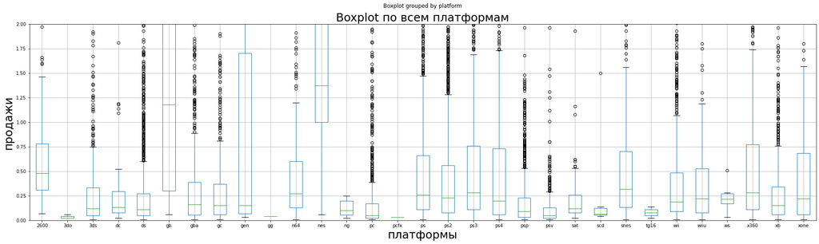

```python
df.boxplot(column='sum_sales', by='platform', figsize=(30,8));
plt.title('Boxplot по всем платформам',fontsize = 25);
plt.xlabel('платформы', fontsize = 25);
plt.ylabel('продажи', fontsize = 25);
plt.ylim(0,2);
plt.show()
```

Есть платформы с гораздо более большими медианами. В данном случае мы смотрим общий период по всем платформам, поэтому это больше исторический экскурс, чем руководство к действию.

Можно сделать вывод, что лидирующие платформы выпускают большой объем игр, и из этого объема выстреливают сверхприбыльные проекты.

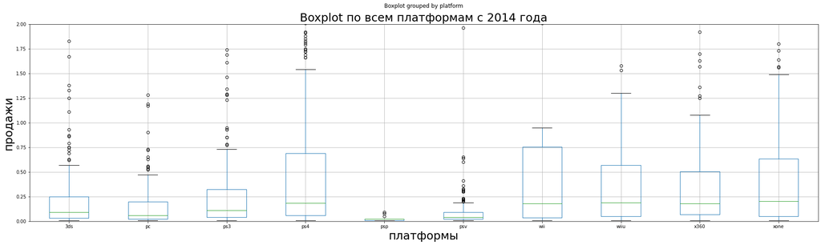

```python
df.query('year_of_release > 2013').boxplot(column='sum_sales', by='platform', figsize=(30,8));
plt.title('Boxplot по всем платформам c 2014 года',fontsize = 25);
plt.xlabel('платформы', fontsize = 25);
plt.ylabel('продажи', fontsize = 25);
plt.ylim(0,2);
plt.show()
```

Действительно в актуальном периоде медианы уже не показывают 1,3 млн проданных копий.

Так же можно отметить, что медианы платформа WIIU, x360, WII находятся в тех же значениях, что и у PS4,XOne.

Размахи больше у лидеров.

75 квантиль у платформы WII больше, чем у лидеров.

Посмотри выбросы всех платформ в актуальном периоде.

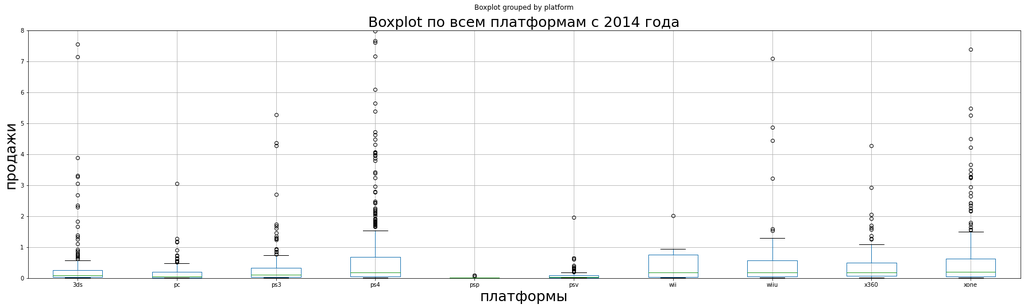

```python
df.query('year_of_release > 2013').boxplot(column='sum_sales', by='platform', figsize=(30,8));
plt.title('Boxplot по всем платформам c 2014 года',fontsize = 25);
plt.xlabel('платформы', fontsize = 25);
plt.ylabel('продажи', fontsize = 25);
plt.ylim(0,8);
plt.show()
```

PS4 и XOne, являются лидерами благодаря выбросам.

Стоит ометить еще платформу 3ds

### Отзовы пользователей и критиков для платформы PS4

```python
df_ps4 = df[df['platform'] == 'ps4'].query('year_of_release > 2013')
df_ps4['sum_sales']= df['sum_sales']*1000000
df_ps4
```

|  | name | platform | year_of_release | genre | na_sales | eu_sales | jp_sales | other_sales | critic_score | user_score | rating | sum_sales |
| --- | --- | --- | --- | --- | --- | --- | --- | --- | --- | --- | --- | --- |
| 31 | call of duty: black ops 3 | ps4 | 2015 | Shooter | 6.03 | 5.86 | 0.36 | 2.38 | NaN | NaN | NaN | 14630000.0 |
| 42 | grand theft auto v | ps4 | 2014 | Action | 3.96 | 6.31 | 0.38 | 1.97 | 97.0 | 8.3 | M | 12620000.0 |
| 77 | fifa 16 | ps4 | 2015 | Sports | 1.12 | 6.12 | 0.06 | 1.28 | 82.0 | 4.3 | E | 8580000.0 |
| 87 | star wars battlefront (2015) | ps4 | 2015 | Shooter | 2.99 | 3.49 | 0.22 | 1.28 | NaN | NaN | NaN | 7980000.0 |
| 92 | call of duty: advanced warfare | ps4 | 2014 | Shooter | 2.81 | 3.48 | 0.14 | 1.23 | 83.0 | 5.7 | M | 7660000.0 |
| ... | ... | ... | ... | ... | ... | ... | ... | ... | ... | ... | ... | ... |
| 16230 | root letter | ps4 | 2016 | Adventure | 0.00 | 0.00 | 0.01 | 0.00 | 69.0 | 7.5 | NaN | 10000.0 |
| 16233 | shin hayarigami 2 | ps4 | 2016 | Adventure | 0.00 | 0.00 | 0.01 | 0.00 | NaN | NaN | NaN | 10000.0 |
| 16255 | dungeons 2 | ps4 | 2016 | Role-Playing | 0.01 | 0.00 | 0.00 | 0.00 | 61.0 | 7.9 | T | 10000.0 |
| 16259 | carmageddon: max damage | ps4 | 2016 | Action | 0.01 | 0.00 | 0.00 | 0.00 | 51.0 | 5.5 | M | 10000.0 |
| 16314 | farming 2017 - the simulation | ps4 | 2016 | Simulation | 0.00 | 0.01 | 0.00 | 0.00 | NaN | NaN | NaN | 10000.0 |

376 rows × 12 columns

```python
df_ps4.describe()
```

|  | year_of_release | na_sales | eu_sales | jp_sales | other_sales | critic_score | user_score | sum_sales |
| --- | --- | --- | --- | --- | --- | --- | --- | --- |
| count | 376.000000 | 376.000000 | 376.000000 | 376.000000 | 376.000000 | 237.000000 | 242.000000 | 3.760000e+02 |
| mean | 2015.236702 | 0.262261 | 0.345851 | 0.039947 | 0.118298 | 72.164557 | 6.828099 | 7.663564e+05 |
| std | 0.762336 | 0.583439 | 0.815480 | 0.067048 | 0.256506 | 12.214985 | 1.399035 | 1.614969e+06 |
| min | 2014.000000 | 0.000000 | 0.000000 | 0.000000 | 0.000000 | 19.000000 | 1.500000 | 1.000000e+04 |
| 25% | 2015.000000 | 0.000000 | 0.000000 | 0.000000 | 0.000000 | 66.000000 | 6.200000 | 5.750000e+04 |
| 50% | 2015.000000 | 0.050000 | 0.070000 | 0.015000 | 0.020000 | 73.000000 | 7.100000 | 1.850000e+05 |
| 75% | 2016.000000 | 0.240000 | 0.280000 | 0.050000 | 0.102500 | 80.000000 | 7.875000 | 6.900000e+05 |
| max | 2016.000000 | 6.030000 | 6.310000 | 0.490000 | 2.380000 | 97.000000 | 9.200000 | 1.463000e+07 |

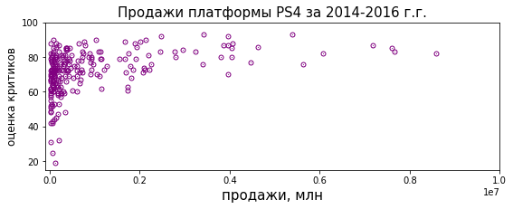

```python
df_ps4.plot(x = 'sum_sales', y = 'critic_score', kind = 'scatter', s= 1, c='purple',
          xlim=(-100000,10000000), ylim=(15,100),figsize = (9,3),linewidth=5);
plt.title('Продажи платформы PS4 за 2014-2016 г.г.',fontsize = 15);
plt.xlabel('продажи, млн', fontsize = 15);
plt.ylabel('оценка критиков', fontsize = 12);
```

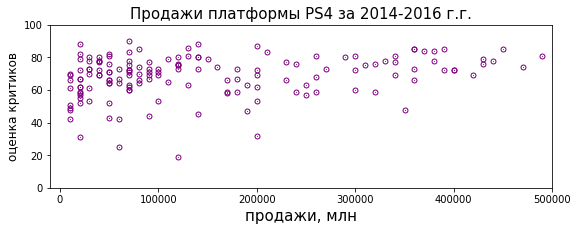

```python
df_ps4.plot(x = 'sum_sales', y = 'critic_score', kind = 'scatter', s= 1, c='purple',
          xlim=(-10000,500000), ylim=(0,100),figsize = (9,3),linewidth=5);
plt.title('Продажи платформы PS4 за 2014-2016 г.г.',fontsize = 15);
plt.xlabel('продажи, млн', fontsize = 15);
plt.ylabel('оценка критиков', fontsize = 12);
```

Отрицательных оценок нет. Возможно не предусмотрены системой оценивания.

На данной платформе довольно высокие оценки критиков 60-80 баллов.

Игры с большими продажами имеют высокую оценку, но при этом игры и с оцень высокой оценкой критиков, более 80 баллов могут иметь не большие продажи. Возможно это "новые" игры, не успели набрать "продажи".

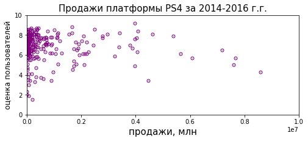

```python
df_ps4.plot(x = 'sum_sales', y = 'user_score', kind = 'scatter', s= 1, c='purple',
          xlim=(0,10000000), ylim=(0,10),figsize = (8,3),linewidth=5);
plt.title('Продажи платформы PS4 за 2014-2016 г.г.',fontsize = 15);
plt.xlabel('продажи, млн', fontsize = 15);
plt.ylabel('оценка пользователей', fontsize = 12);
```

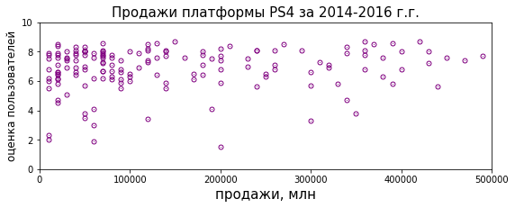

```python
df_ps4.plot(x = 'sum_sales', y = 'user_score', kind = 'scatter', s= 1, c='purple',
          xlim=(0,500000), ylim=(0,10),figsize = (9,3),linewidth=5);
plt.title('Продажи платформы PS4 за 2014-2016 г.г.',fontsize = 15);
plt.xlabel('продажи, млн', fontsize = 15);
plt.ylabel('оценка пользователей', fontsize = 12);
```

По графикам оценки пользователей и критиков распределены похожим образом. Можно отметить, что игры с не маленькими продажами, могут получать от пользователей более низкую оценку, чем от критиков.

Игры с максимальными продажами (более 6 млн.) оценены пользователями и критиками по разному. Критики оценили эти игры очень высоко 82-87 баллов, в то время как оценка пользователей была более низкой 4-6 баллов.

```python
df_ps4_cor = df_ps4['critic_score'].corr(df_ps4['sum_sales'])
print('Корреляция:',df_ps4_cor)
```

```
Корреляция: 0.402661410681041
```

```python
df_ps4_cor = df_ps4['user_score'].corr(df_ps4['sum_sales'])
print('Корреляция:',df_ps4_cor)
```

```
Корреляция: -0.04013158947269734
```

Корреляция между оценками критиков и продажами умеренная, корреляция между оценками пользователей и продажами слабая. Можно сказать, что критики лучше оценивают игры, но незначительно "лучше". Принимать оценку критиков как достоверную для прогноза продаж не стоит.

```python
df_score = df.query('year_of_release > 2013')
df_score = df_score.pivot_table(index = 'platform',
                                values = ['sum_sales','critic_score','user_score'] , aggfunc = ['sum','median'])
df_score
```

| platform | sum critic_score | sum sum_sales | sum user_score | median critic_score | median sum_sales | median user_score |
| --- | --- | --- | --- | --- | --- | --- |
| 3ds | 3518.0 | 86.68 | 392.6 | 69.0 | 0.090 | 7.40 |
| pc | 8841.0 | 27.05 | 768.4 | 77.0 | 0.060 | 6.80 |
| ps3 | 2396.0 | 68.18 | 589.4 | 67.0 | 0.110 | 6.55 |
| ps4 | 17103.0 | 288.15 | 1652.4 | 73.0 | 0.185 | 7.10 |
| psp | 0.0 | 0.36 | 0.0 | NaN | 0.020 | NaN |
| psv | 3902.0 | 22.40 | 558.9 | 72.0 | 0.040 | 7.80 |
| wii | 0.0 | 5.07 | 12.7 | NaN | 0.180 | 6.35 |
| wiiu | 3061.0 | 42.98 | 340.2 | 73.0 | 0.190 | 7.10 |
| x360 | 1657.0 | 48.22 | 479.0 | 67.0 | 0.180 | 6.00 |
| xone | 11438.0 | 140.36 | 1088.1 | 76.0 | 0.205 | 6.80 |

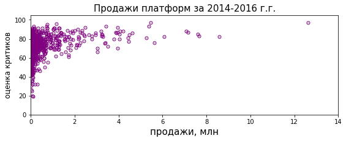

```python
df.query('year_of_release > 2013').plot(x = 'sum_sales', y = 'critic_score', kind = 'scatter', s= 1, c='purple',
          xlim=(0,14), ylim= (0,105),figsize = (9,3),linewidth=5);
plt.title('Продажи платформ за 2014-2016 г.г.',fontsize = 15);
plt.xlabel('продажи, млн', fontsize = 15);
plt.ylabel('оценка критиков', fontsize = 12);
```

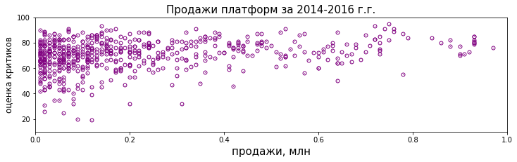

```python
df.query('year_of_release > 2013').plot(x = 'sum_sales', y = 'critic_score', kind = 'scatter', s= 1, c='purple',
          xlim=(0,1), ylim= (10,100),figsize = (12,3),linewidth=5);
plt.title('Продажи платформ за 2014-2016 г.г.',fontsize = 15);
plt.xlabel('продажи, млн', fontsize = 15);
plt.ylabel('оценка критиков', fontsize = 12);
```

За актуальные период представлено 8 платформ с оценками критиков. Рассмотрим из все.

Распределение такое же как и у одной платформы PS4

Оценки критиков находятся в диапазоне 60-80 баллов. На общем графике больше низких оценок, чем у PS4

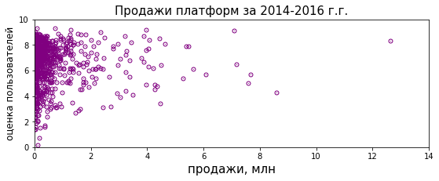

```python
df.query('year_of_release > 2013').plot(x = 'sum_sales', y = 'user_score', kind = 'scatter', s= 1, c='purple',
          xlim=(0,14), ylim= (0,10),figsize = (9,3),linewidth=5);
plt.title('Продажи платформ за 2014-2016 г.г.',fontsize = 15);
plt.xlabel('продажи, млн', fontsize = 15);
plt.ylabel('оценка пользователей', fontsize = 12);
```

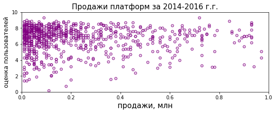

```python
df.query('year_of_release > 2013').plot(x = 'sum_sales', y = 'user_score', kind = 'scatter', s= 1, c='purple',
          xlim=(0,1), ylim= (0,10),figsize = (9,3),linewidth=5);
plt.title('Продажи платформ за 2014-2016 г.г.',fontsize = 15);
plt.xlabel('продажи, млн', fontsize = 15);
plt.ylabel('оценка пользователей', fontsize = 12);
```

Оценки пользователей распределены похожим образом у 9 платформ, по сравнению с одной платформой.

### Продажи по всем платформам

```python
df_sale =  df.pivot_table(index = "platform", values ='sum_sales', aggfunc = 'sum')
df_sale.sort_values(by='sum_sales',ascending = False).head(5)
```

| platform | sum_sales |
| --- | --- |
| ps2 | 1233.56 |
| x360 | 961.24 |
| ps3 | 931.33 |
| wii | 891.18 |
| ds | 802.78 |

```python
df.groupby('platform')['sum_sales'].describe().sort_values(by='mean',ascending = False)
```

| platform | count | mean | std | min | 25% | 50% | 75% | max |
| --- | --- | --- | --- | --- | --- | --- | --- | --- |
| gb | 97.0 | 2.622990 | 5.390925 | 0.06 | 0.3000 | 1.180 | 2.1800 | 31.38 |
| nes | 98.0 | 2.561735 | 5.108012 | 0.06 | 1.0000 | 1.375 | 2.2225 | 40.24 |
| gen | 27.0 | 1.050000 | 1.490041 | 0.03 | 0.0700 | 0.150 | 1.7050 | 6.02 |
| snes | 239.0 | 0.836987 | 1.869469 | 0.01 | 0.1350 | 0.320 | 0.7050 | 20.62 |
| ps4 | 392.0 | 0.801378 | 1.609456 | 0.01 | 0.0600 | 0.200 | 0.7300 | 14.63 |
| x360 | 1232.0 | 0.780227 | 1.632122 | 0.01 | 0.1100 | 0.280 | 0.7700 | 21.82 |
| 2600 | 116.0 | 0.745517 | 0.956160 | 0.07 | 0.3075 | 0.480 | 0.7800 | 7.81 |
| ps3 | 1305.0 | 0.713663 | 1.403467 | 0.00 | 0.1100 | 0.280 | 0.7600 | 21.05 |
| wii | 1286.0 | 0.692986 | 3.165022 | 0.01 | 0.0900 | 0.190 | 0.4875 | 82.54 |
| n64 | 316.0 | 0.689905 | 1.322189 | 0.01 | 0.1300 | 0.270 | 0.6000 | 11.90 |
| xone | 247.0 | 0.645020 | 1.036139 | 0.01 | 0.0600 | 0.220 | 0.6850 | 7.39 |
| ps | 1190.0 | 0.611412 | 1.056807 | 0.01 | 0.1100 | 0.260 | 0.6600 | 10.95 |
| ps2 | 2127.0 | 0.579953 | 1.138461 | 0.00 | 0.0800 | 0.230 | 0.5600 | 20.81 |
| wiiu | 147.0 | 0.559116 | 1.058836 | 0.01 | 0.0800 | 0.220 | 0.5250 | 7.09 |
| 3ds | 512.0 | 0.503535 | 1.441271 | 0.01 | 0.0500 | 0.120 | 0.3325 | 14.60 |
| gba | 811.0 | 0.385795 | 0.899654 | 0.01 | 0.0550 | 0.160 | 0.3900 | 15.84 |
| ds | 2121.0 | 0.378491 | 1.436042 | 0.01 | 0.0500 | 0.110 | 0.2700 | 29.80 |
| gc | 542.0 | 0.362970 | 0.693974 | 0.01 | 0.0600 | 0.150 | 0.3675 | 7.06 |
| xb | 803.0 | 0.313288 | 0.539309 | 0.01 | 0.0600 | 0.150 | 0.3400 | 8.48 |
| scd | 6.0 | 0.310000 | 0.584055 | 0.04 | 0.0525 | 0.065 | 0.1225 | 1.50 |
| dc | 52.0 | 0.306731 | 0.468660 | 0.02 | 0.0775 | 0.135 | 0.2975 | 2.41 |
| pc | 956.0 | 0.267490 | 0.680061 | 0.01 | 0.0200 | 0.050 | 0.1700 | 8.01 |
| psp | 1193.0 | 0.242691 | 0.522019 | 0.01 | 0.0300 | 0.090 | 0.2300 | 7.68 |
| ws | 6.0 | 0.236667 | 0.159457 | 0.03 | 0.1725 | 0.215 | 0.2725 | 0.51 |
| sat | 173.0 | 0.194162 | 0.218092 | 0.02 | 0.0800 | 0.120 | 0.2600 | 1.93 |
| psv | 429.0 | 0.125431 | 0.212341 | 0.01 | 0.0200 | 0.050 | 0.1300 | 1.96 |
| ng | 12.0 | 0.120000 | 0.082241 | 0.02 | 0.0550 | 0.100 | 0.2000 | 0.25 |
| tg16 | 2.0 | 0.080000 | 0.084853 | 0.02 | 0.0500 | 0.080 | 0.1100 | 0.14 |
| gg | 1.0 | 0.040000 | NaN | 0.04 | 0.0400 | 0.040 | 0.0400 | 0.04 |
| 3do | 3.0 | 0.033333 | 0.023094 | 0.02 | 0.0200 | 0.020 | 0.0400 | 0.06 |
| pcfx | 1.0 | 0.030000 | NaN | 0.03 | 0.0300 | 0.030 | 0.0300 | 0.03 |

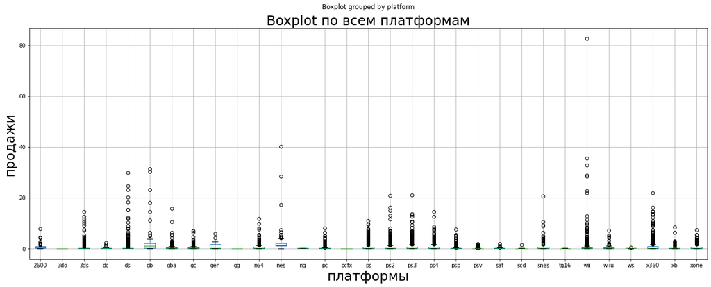

```python
df.boxplot(column='sum_sales', by='platform', figsize=(22,8));
plt.title('Boxplot по всем платформам',fontsize = 25);
plt.xlabel('платформы', fontsize = 25);
plt.ylabel('продажи', fontsize = 25);
```

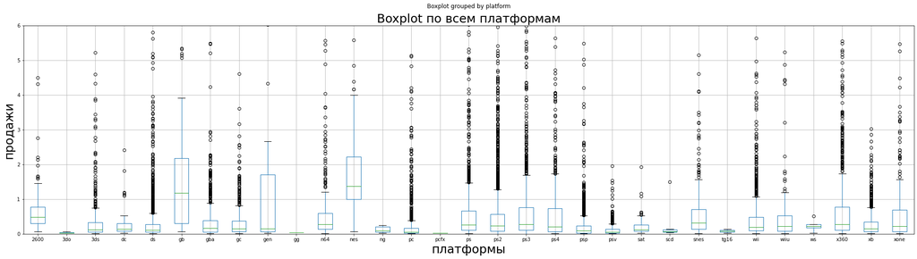

```python
df.boxplot(column='sum_sales', by='platform', figsize=(32,8));
plt.title('Boxplot по всем платформам',fontsize = 25);
plt.xlabel('платформы', fontsize = 25);
plt.ylabel('продажи', fontsize = 25);
plt.ylim(0,6);
plt.show()
```

Boxplot дает возможность увидеть платформы с большим количество игр. Считаю, что платформы у которых много выбросов, имеют большое количество игр. Это PS2, DS, PC, PSP и т.д.

### Как жанры влияют на продажи

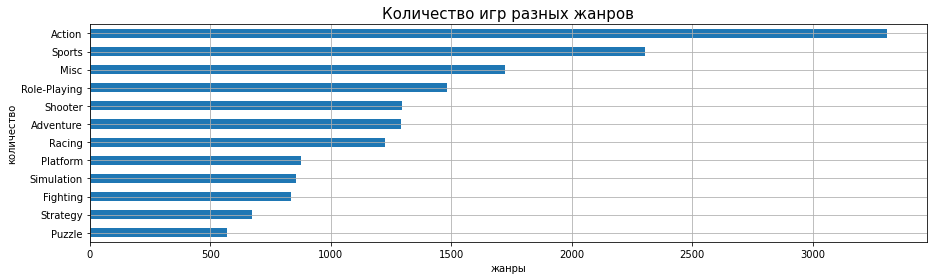

```python
df_genre_1 = df.pivot_table(index=['genre'], values = ['sum_sales'],aggfunc ='count').sort_values(
    by = 'sum_sales',ascending = True)
df_genre_1.plot(kind = 'barh',figsize = (15,4),grid=True, legend = False);
plt.title('Количество игр разных жанров',fontsize = 15);
plt.xlabel('жанры', fontsize = 10);
plt.ylabel('количество', fontsize = 10);
```

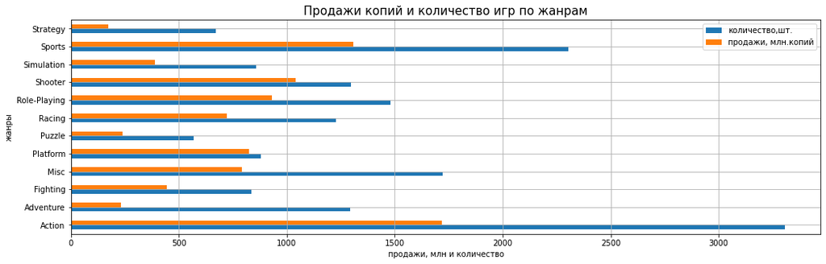

```python
df_genre = df.pivot_table(index=['genre'], values = ['sum_sales'],aggfunc ={'sum','count'})
df_genre.plot(kind = 'barh',figsize = (17,5),grid=True, legend = True);
plt.title('Продажи копий и количество игр по жанрам',fontsize = 15);
plt.xlabel('продажи, млн и количество', fontsize = 10);
plt.ylabel('жанры', fontsize = 10);
plt.legend(['количество,шт.','продажи, млн.копий'], fontsize = 10, loc=0);
```

```python
df_genre_tabl = df.pivot_table(index='genre', values = 'sum_sales', aggfunc = 'sum').sort_values(
    by = 'sum_sales',ascending = False)
df_genre_tabl = df_genre_tabl.head(5)
df_genre_tabl
```

| genre | sum_sales |
| --- | --- |
| Action | 1716.52 |
| Sports | 1309.66 |
| Shooter | 1041.36 |
| Role-Playing | 931.08 |
| Platform | 825.55 |

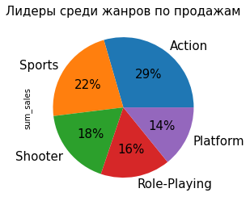

```python
df_genre_tabl.plot(x = 'genre', y = 'sum_sales', kind = 'pie',
                            figsize = (14,4),  grid=True, legend = False, fontsize = 15,autopct='%1.0f%%');
plt.title('Лидеры среди жанров по продажам',fontsize = 15);
```

Action и Sports любимые жанры у пользователей и производителей игр.

Жанры оказывают определенное влияние на продажи. Интересно. почему в жанре Adventure выпущено достаточно много игр, но копий продано мало. Просто не нравятся покупателям или нужно смотреть периоды, или платформы...

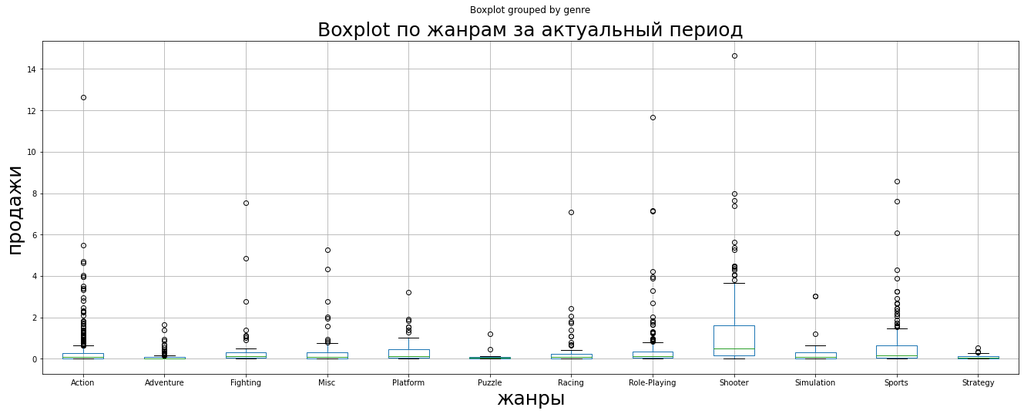

```python
df.query('year_of_release > 2013').boxplot(column='sum_sales', by='genre', figsize=(22,8));
plt.title('Boxplot по жанрам за актуальный период',fontsize = 25);
plt.xlabel('жанры', fontsize = 25);
plt.ylabel('продажи', fontsize = 25);
plt.show()
```

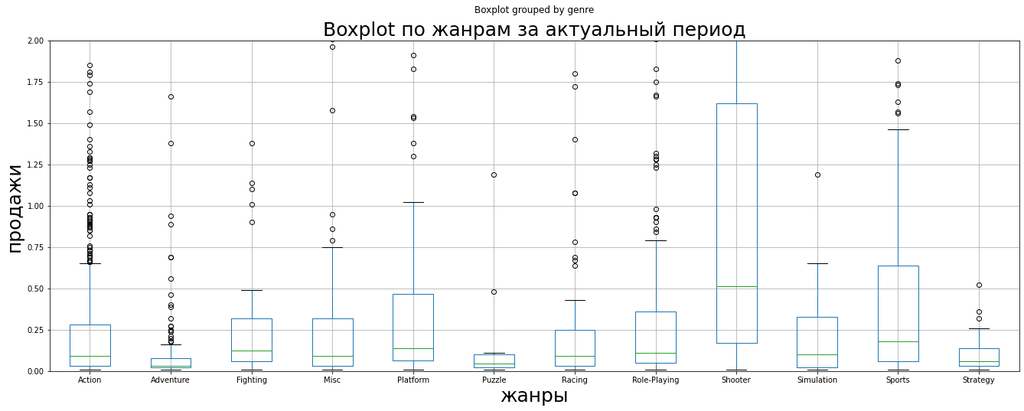

```python
df.query('year_of_release > 2013').boxplot(column='sum_sales', by='genre', figsize=(22,8));
plt.title('Boxplot по жанрам за актуальный период',fontsize = 25);
plt.xlabel('жанры', fontsize = 25);
plt.ylabel('продажи', fontsize = 25);
plt.ylim(0,2);
plt.show()
```

```python
df_genre_des = df.query('year_of_release > 2013')
df_genre_des =df_genre_des.pivot_table(index='genre',values = ['sum_sales','name'],aggfunc = {'sum_sales':'median','name':'count'})
df_genre_des.columns = ['count', 'median_sum_sales']
df_genre_des.sort_values('median_sum_sales',ascending=False)
```

| genre | count | median_sum_sales |
| --- | --- | --- |
| Shooter | 128 | 0.515 |
| Sports | 161 | 0.180 |
| Platform | 38 | 0.140 |
| Fighting | 60 | 0.125 |
| Role-Playing | 221 | 0.110 |
| Simulation | 44 | 0.100 |
| Action | 619 | 0.090 |
| Misc | 113 | 0.090 |
| Racing | 69 | 0.090 |
| Strategy | 37 | 0.060 |
| Puzzle | 14 | 0.045 |
| Adventure | 185 | 0.030 |

Самая большая медиана продаж у жанра Shooter. У этого жанра есть лидер продаж с очень большим результатом.

Так же у жанра Action есть лидер по продажам.

Жанр Role-Playing, не смотря на не высокую медиану, так же имеет удачную игру.

Для рекламной компании рекомендую жанры Shooter, Action, Sports и Role-Playing